# Data_wrangling_Project

## 3 North Carolina weather station

```
##    Year    T   TM   Tm      PP    V
## 1  1941  0.0  0.0  0.0    0.00  0.0
## 2  1942 15.8 21.9 10.8    0.00  9.6
## 3  1943 16.0 22.3 10.8    0.00 12.2
## 4  1944  0.0  0.0  0.0    0.00  0.0
## 5  1973 15.3 21.8  9.6    0.00 13.5
## 6  1974 15.4 22.6  9.2    0.00 13.0
## 7  1975 15.9 22.6  9.7    0.00 11.2
## 8  1976 14.7 22.0  7.9    0.00 11.9
## 9  1977 15.7 22.7  9.5    0.00 11.6
## 10 1978 15.4 22.5  9.0    0.00 11.3
## 11 1979 14.9 21.9  8.6 1547.11 12.1
## 12 1980 15.3 22.2  9.0 1099.00 12.1
## 13 1981 15.0 22.1  8.4  979.24 12.1
## 14 1982 15.6 22.4  9.8 1190.70 11.3
```

[output cut: 36 more lines]

Similar to Texas, there are more than one climate stations located in North carolina. I scraped them off, convert each columns into numeric, select the interested variables we want to include, and merge these three data frames into one using “join_all” method. Now we have the new data frame, which I arrange by year to see the general results.

Using ggplot to plot NC min and max temperature over the years

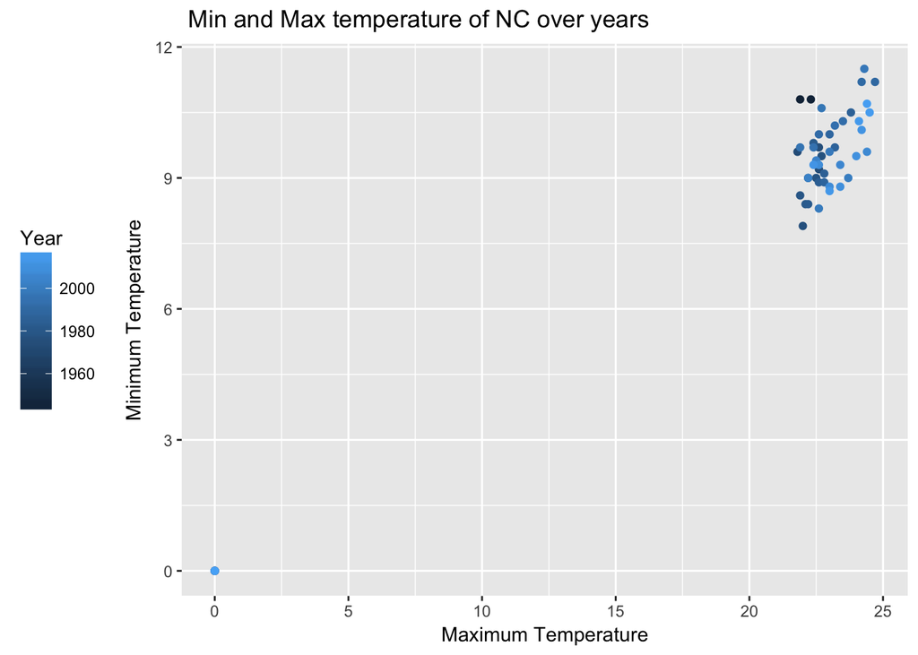

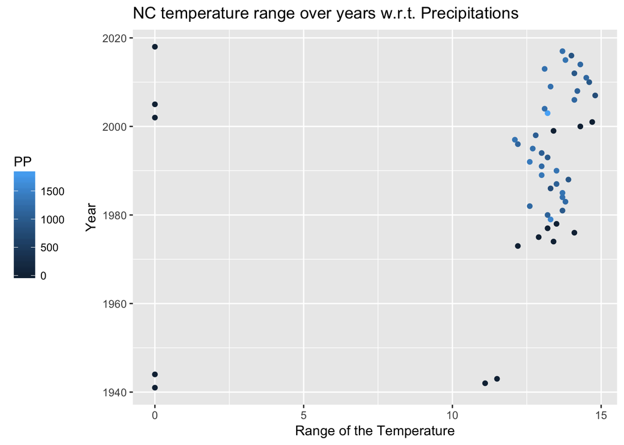

[citation: US Department of Commerce, and NOAA. “Snowstorm of the Century March 1980.” National Weather Service, NOAA’s National Weather Service, 14 Jan. 2016, www.weather.gov/mhx/Mar011980EventReview.]

Tentative web-scraping technique. Trying to write a function that can scrap tables off from multiple url links, since the url only changed when changing the climate stations (each climate stations have its own code) however, did not work :(

#### Second. Importing second dataset we want to use and compare in this project

Using ggplot to plot the min and max temperature

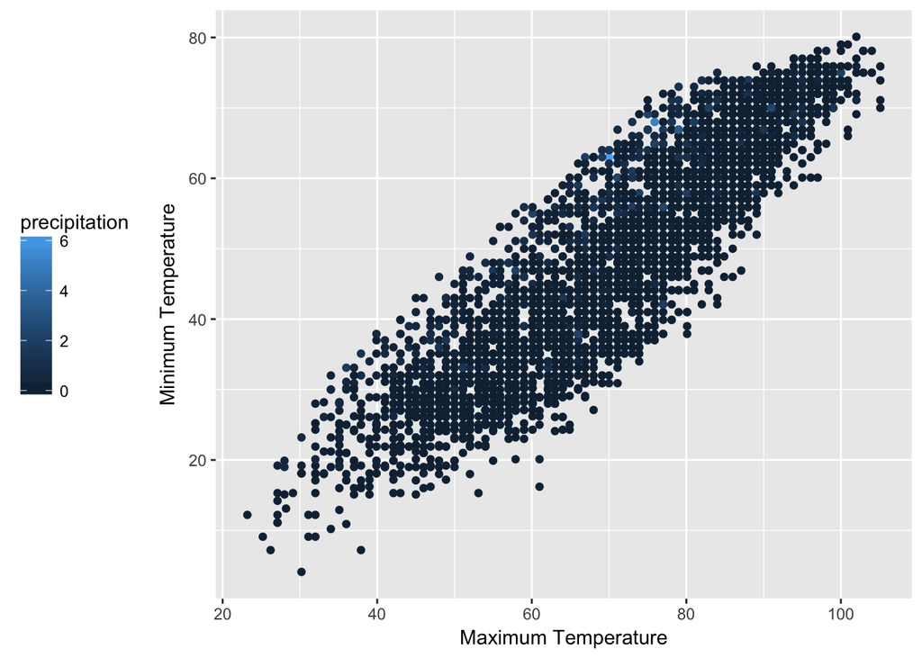

To compare the range of the temperature from this dataset with the previous join_nc dataset, we use similar method to add columns into the original dataset.

```
## # A tibble: 7 x 9
## # Groups:   Year [7]
##    Year     T    TM    Tm    PP     V median_PP average_PP range_T
##   <dbl> <dbl> <dbl> <dbl> <dbl> <dbl>     <dbl>      <dbl>   <dbl>
## 1  2010  16.0  23.4  8.80   947  9.10      1043        800    14.6
## 2  2011  16.7  24.0  9.50  1178  9.60      1043        800    14.5
## 3  2012  16.9  24.2 10.1    948  9.00      1043        800    14.1
## 4  2013  15.6  22.4  9.30  1290  9.70      1043        800    13.1
## 5  2014  15.6  23.0  8.70  1186  9.50      1043        800    14.3
## 6  2015  17.0  24.1 10.3   1323  9.80      1043        800    13.8
## 7  2016  17.3  24.5 10.5    888 10.2       1043        800    14.0
```

RUIXUAN SONG 4/29/2018